# NLP

Charles Lang

## Libraries

```r
#Make sure you install and load the following libraries

library(tm)
```

```r
library(SnowballC)
library(wordcloud)
library(ggplot2)
library(tidyverse) #You will need the full tidyverse package not tidyr and dyplr separately
library(topicmodels)

#IF USING A MAC PLEASE RUN THIS CODE
Sys.setlocale("LC_ALL", "C")
```

```
## [1] "C"
```

## In the class-notes folder you will find real csv files exported from real student’s note taking in this class. Import all document files and the list of weeks file

```r
library(tidyverse)

#Create a list of all the files, then loop over file list importing them and binding them together
D1 <- list.files(path = "C:/Users/BEIB/Desktop/A/4051/R/Xingyixie_natural-language-processing/class-notes/",
               pattern = "*.csv",
               full.names = T) %>%
    map_df(~read_csv(., col_types = cols(.default = "c")))
```

## Step 1 - Clean

```r
#Separate out the variables of interest
D1 <- select(D1, Title, Notes)

#Remove the htlm tags from your text
D1$Notes <- gsub("<.*?>", "", D1$Notes)
D1$Notes <- gsub("nbsp", "" , D1$Notes)
D1$Notes <- gsub("nbspnbspnbsp", "" , D1$Notes)
D1$Notes <- gsub("<U+00A0><U+00A0><U+00A0>", "" , D1$Notes)

#Merge the weeks data with your notes data so that each line has a week attributed to it

#Also remove readings not belonging to the class (IE - that are NA for week)
```

## Step 2 - Process text using the tm package

```r
#Convert the data frame to the corpus format that the tm package uses
corpus <- VCorpus(VectorSource(D1$Notes))
#Remove spaces
corpus <- tm_map(corpus, stripWhitespace)
#Convert to lower case
corpus <- tm_map(corpus, tolower)
#Remove pre-defined stop words ('the', 'a', etc)
corpus <- tm_map(corpus, removeWords, stopwords('english'))
#Convert words to stems ("education" = "edu") for analysis, for more info see  http://tartarus.org/~martin/PorterStemmer/
corpus <- tm_map(corpus, stemDocument)
#Remove numbers
corpus <- tm_map(corpus, removeNumbers)
#remove punctuation
corpus <- tm_map(corpus, removePunctuation)
#Convert to plain text for mapping by wordcloud package
corpus <- tm_map(corpus, PlainTextDocument, lazy = TRUE)

#Convert corpus to a term document matrix - so each word can be analyzed individuallly
tdm.corpus <- TermDocumentMatrix(corpus)

#Note: we won't remove plural words here, plural words in English tend to be highly irregular and difficult to extract reliably
```

What processing steps have you conducted here? Why is this important? Are there any other steps you should take to process your text before analyzing?

##The above processes the text by removing spaces, case conversion, deactivating words, converting near-synonyms, removing numbers, removing punctuation, etc. ##Before these processes we can also de-duplicate the text, phrase processing, mechanical compression processing, and remove some meaningless text.

## Step 3 - Find common words

```r
#The tm package can do some simple analysis, like find the most common words
findFreqTerms(tdm.corpus, lowfreq=500, highfreq=Inf)
```

```
##  [1] "also"     "analysi"  "analyt"   "can"      "data"     "differ"
##  [7] "educ"     "inform"   "knowledg" "learn"    "make"     "measur"
## [13] "method"   "model"    "network"  "predict"  "research" "set"
## [19] "skill"    "student"  "use"
```

```r
#We can also create a vector of the word frequencies that can be useful to see common and uncommon words
word.count <- sort(rowSums(as.matrix(tdm.corpus)), decreasing=TRUE)
word.count <- data.frame(word.count)
#Look at the word.count dataframe
```

## Generate a Word Cloud

### ColorBrewer

ColorBrewer is a useful tool to help you choose colors for visualizations that was originally built for cartographers. On the ColorBrewer website (http://colorbrewer2.org/#) you can test different color schemes or see what their preset color schemes look like. This is very useful, especially if you are making images for colorblind individuals.

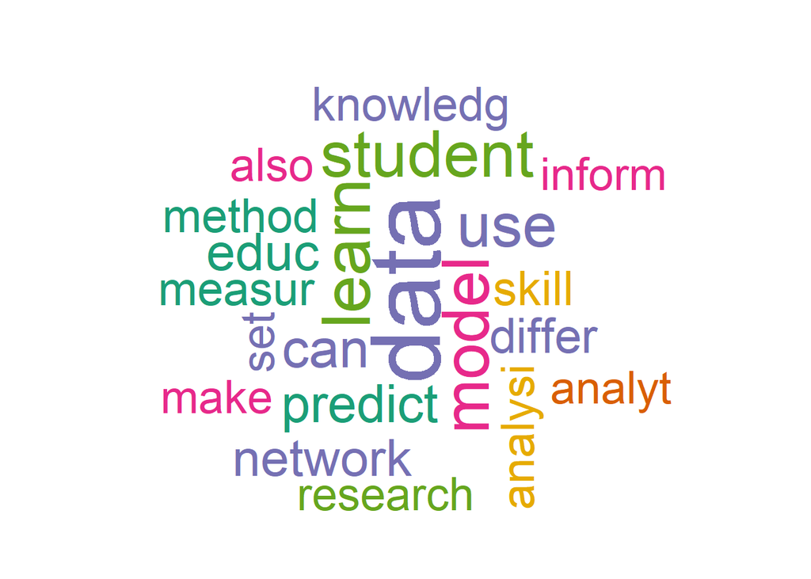

```r
#Define the colors the cloud will use
col=brewer.pal(6,"Dark2")
#Generate cloud, make sure your window is large enough to see it
wordcloud(corpus, min.freq=500, scale=c(5,2),rot.per = 0.25,
          random.color=T, max.word=45, random.order=F,colors=col)
```

# Sentiment Analysis

### Match words in corpus to lexicons of positive & negative words

```r
#Upload positive and negative word lexicons
positive <- readLines("positive-words.txt")
negative <- readLines("negative-words.txt")

#Search for matches between each word and the two lexicons
D1$positive <- tm_term_score(tdm.corpus, positive)
D1$negative <- tm_term_score(tdm.corpus, negative)

#Generate an overall pos-neg score for each line
D1$score <- D1$positive - D1$negative
```

## Using ggplot Generate a visualization of the mean sentiment score over weeks, remove rows that have readings from other classes (NA for weeks). You will need to summarize your data to achieve this.

```r
library(sqldf)
library(gsubfn)
library(proto)
library(RSQLite)
library(lubridate)
```

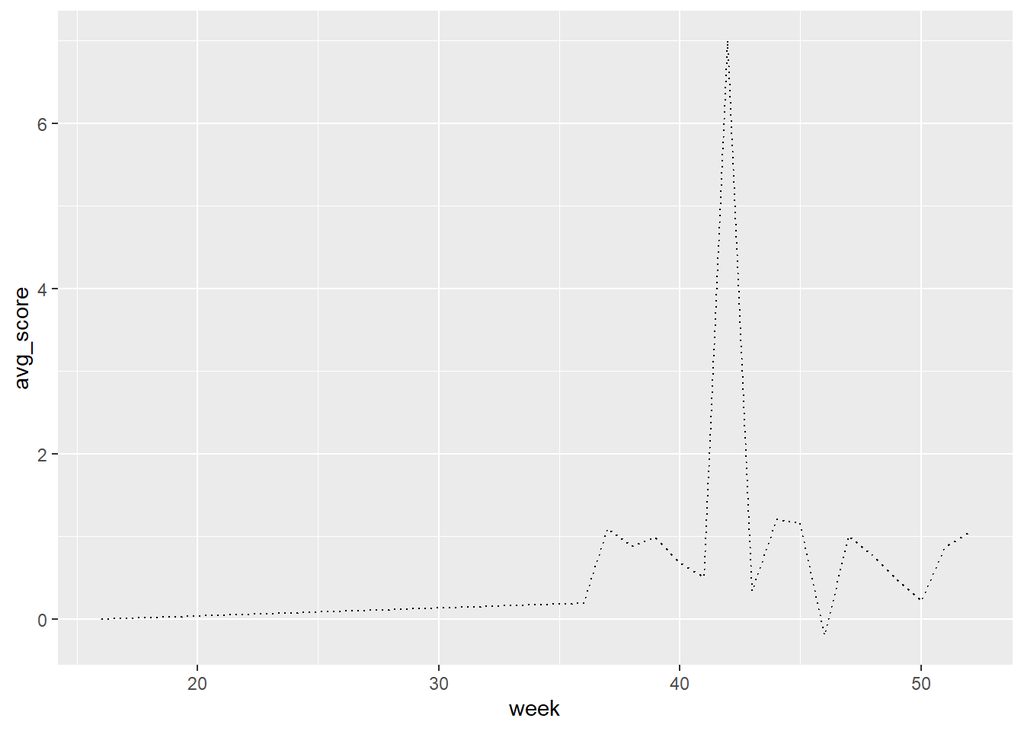

```r
library(ggplot2)
D2 <- list.files(path = "C:/Users/BEIB/Desktop/A/4051/R/Xingyixie_natural-language-processing/class-notes/",
               pattern = "*.csv",
               full.names = T) %>%
    map_df(~read_csv(., col_types = cols(.default = "c")))
df_list <- cbind(D1,subset(D2, select = `Date Added` ))
df_list$`Date Added`<-as.Date(df_list$`Date Added`,format="%Y-%m-%d")
df_list$week<-week(df_list$`Date Added`)
score_mean<-sqldf("select week ,avg(score) avg_score from df_list group by week")
ggplot(score_mean, aes(x=week, y=avg_score, group=1)) + geom_line(linetype="dotted")
```